# Pemodelan ARIMA pada Data Beijing Air Quality

Adi Pratama

1 Oktober 2026

# 1 Pendahuluan

Analisis pada tugas ini menggunakan data **Beijing Air Quality** untuk membangun model **ARIMA.** Variabel yang dimodelkan adalah nilai median konsentrasi **PM2.5** harian.

Tahapan analisis mengikuti alur pemodelan deret waktu pada praktikum, yaitu:

1. pembagian data menjadi data train dan test;
2. pemeriksaan stasioneritas dalam rataan menggunakan ACF dan ADF;
3. pemeriksaan stasioneritas dalam ragam menggunakan Box-Cox;
4. transformasi dan/atau differencing apabila diperlukan;
5. identifikasi model potensial menggunakan ACF, PACF, dan EACF;
6. pendugaan parameter dan pemilihan model berdasarkan signifikansi parameter serta AIC;
7. analisis sisaan;
8. pemeriksaan overfitting;
9. peramalan dan evaluasi hasil forecast.

# 2 Packages

```r
library (readxl)
library(readr)
library(dplyr)
library(ggplot2)
library(forecast)
library(tseries)
library(TSA)
library(MASS)
library(lmtest)
library(car)
```

# 3 Data dan Persiapan

## 3.1 Import Data

```r
data_raw <- read_csv(
  "Beijing Air Quality Data 2024-2026.csv",
  show_col_types = FALSE
)

str(data_raw)
```

```
#> spc_tbl_ [973 × 9] (S3: spec_tbl_df/tbl_df/tbl/data.frame)
#>  $ Date    : chr [1:973] "1/1/2024" "2/1/2024" "3/1/2024" "4/1/2024" ...
#>  $ Country : chr [1:973] "CN" "CN" "CN" "CN" ...
#>  $ City    : chr [1:973] "Beijing" "Beijing" "Beijing" "Beijing" ...
#>  $ Specie  : chr [1:973] "pm25" "pm25" "pm25" "pm25" ...
#>  $ count   : num [1:973] 263 270 259 281 267 244 258 286 288 280 ...
#>  $ min     : num [1:973] 50 9 5 5 5 5 21 61 5 17 ...
#>  $ max     : num [1:973] 211 220 163 177 164 134 117 157 157 183 ...
#>  $ median  : num [1:973] 154 165 42 155 87 21 50 122 87 65 ...
#>  $ variance: num [1:973] 12938 28644 28404 39255 21019 ...
#>  - attr(*, "spec")=
#>   .. cols(
#>   ..   Date = col_character(),
#>   ..   Country = col_character(),
#>   ..   City = col_character(),
#>   ..   Specie = col_character(),
#>   ..   count = col_double(),
#>   ..   min = col_double(),
#>   ..   max = col_double(),
#>   ..   median = col_double(),
#>   ..   variance = col_double()
#>   .. )
#>  - attr(*, "problems")=<pointer: 0x00000215493ff840>
```

```r
head(data_raw)
```

```
#> # A tibble: 6 × 9
#>   Date     Country City    Specie count   min   max median variance
#>   <chr>    <chr>   <chr>   <chr>  <dbl> <dbl> <dbl>  <dbl>    <dbl>
#> 1 1/1/2024 CN      Beijing pm25     263    50   211    154   12938.
#> 2 2/1/2024 CN      Beijing pm25     270     9   220    165   28644.
#> 3 3/1/2024 CN      Beijing pm25     259     5   163     42   28404.
#> 4 4/1/2024 CN      Beijing pm25     281     5   177    155   39255.
#> 5 5/1/2024 CN      Beijing pm25     267     5   164     87   21019.
#> 6 6/1/2024 CN      Beijing pm25     244     5   134     21    5545.
```

Data kemudian diperiksa untuk mengetahui struktur variabel, periode pengamatan, dan kemungkinan adanya tanggal yang terduplikasi.

```r
cat("Jumlah baris awal :", nrow(data_raw), "\n")
```

```
#> Jumlah baris awal : 973
```

```r
cat("Jumlah kolom      :", ncol(data_raw), "\n")
```

```
#> Jumlah kolom      : 9
```

```r
cat("Jumlah tanggal unik:", length(unique(data_raw$Date)), "\n")
```

```
#> Jumlah tanggal unik: 966
```

## 3.2 Persiapan Variabel

Pada analisis ARIMA ini akan digunakan variabel `median` PM2.5 pada setiap tanggal.

```r
data <- data_raw %>%
  mutate(Date = as.Date(Date, format = "%d/%m/%Y")) %>%
  arrange(Date)

# Cek jumlah tanggal duplikat
jumlah_duplikat <- sum(duplicated(data$Date))
jumlah_duplikat
```

```
#> [1] 7
```

```r
data <- data %>%
  distinct(Date, .keep_all = TRUE) %>%
  dplyr::select(Date, median)

# Pastikan data tersusun berdasarkan waktu
data <- data %>%
  arrange(Date)

summary(data)
```

```
#>       Date                median
#>  Min.   :2024-01-01   Min.   : 13.00
#>  1st Qu.:2024-08-29   1st Qu.: 46.00
#>  Median :2025-04-27   Median : 70.00
#>  Mean   :2025-04-27   Mean   : 80.33
#>  3rd Qu.:2025-12-24   3rd Qu.:107.00
#>  Max.   :2026-08-23   Max.   :238.00
```

Setelah tanggal duplikat dihapus, data yang digunakan dalam analisis merupakan satu observasi untuk setiap tanggal dan berjumlah 966.

```r
cat("Jumlah observasi :", nrow(data), "\n")
```

```
#> Jumlah observasi : 966
```

```r
cat("Tanggal awal     :", format(min(data$Date)), "\n")
```

```
#> Tanggal awal     : 2024-01-01
```

```r
cat("Tanggal akhir    :", format(max(data$Date)), "\n")
```

```
#> Tanggal akhir    : 2026-08-23
```

```r
cat("NA pada median   :", sum(is.na(data$median)), "\n")
```

```
#> NA pada median   : 0
```

Apabila masih terdapat nilai hilang pada variabel yang digunakan, nilai tersebut perlu ditangani sebelum membentuk objek deret waktu.

```r
data <- data %>%
  filter(!is.na(median))
```

# 4 Eksplorasi Data

## 4.1 Statistik Deskriptif

```r
summary(data$median)
```

```
#>    Min. 1st Qu.  Median    Mean 3rd Qu.    Max.
#>   13.00   46.00   70.00   80.33  107.00  238.00
```

```r
deskriptif <- data.frame(
  Mean = mean(data$median),
  Median = median(data$median),
  SD = sd(data$median),
  Minimum = min(data$median),
  Maximum = max(data$median)
)

deskriptif
```

```
#>       Mean Median       SD Minimum Maximum
#> 1 80.33126     70 44.97592      13     238
```

## 4.2 Plot Deret Waktu

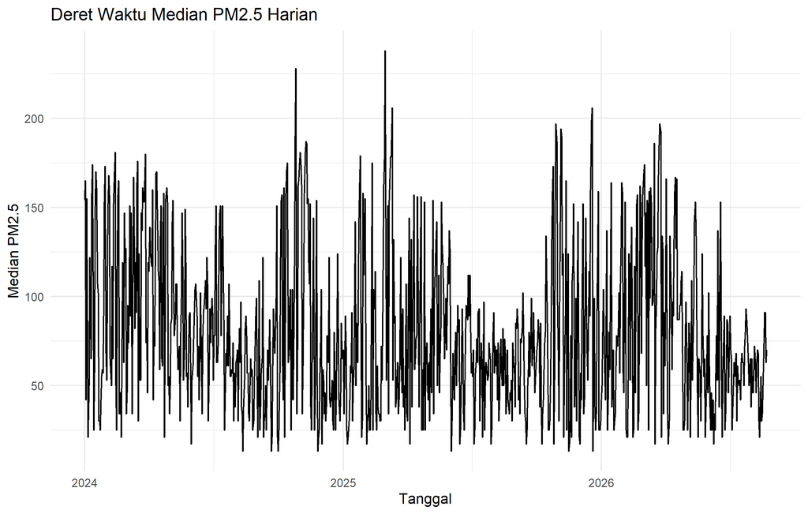

```r
ggplot(data, aes(x = Date, y = median)) +
  geom_line(linewidth = 0.6) +
  labs(
    title = "Deret Waktu Median PM2.5 Harian",
    x = "Tanggal",
    y = "Median PM2.5"
  ) +
  theme_minimal()
```

Plot ini digunakan sebagai pemeriksaan awal untuk melihat pola data, kecenderungan, perubahan ragam, serta kemungkinan pola musima.

## 4.3 Pembagian Data Train dan Test

Data dibagi menjadi data train dan data test. Pada analisis ini digunakan 20% observasi terakhir sebagai data test, sedangkan 80% observasi awal digunakan sebagai data train.

```r
test_size <- floor(0.20 * nrow(data))

train <- data %>%
  slice(1:(n() - test_size))

test <- data %>%
  slice((n() - test_size + 1):n())

cat("Jumlah train :", nrow(train), "\n")
```

```
#> Jumlah train : 773
```

```r
cat("Jumlah test  :", nrow(test), "\n")
```

```
#> Jumlah test  : 193
```

```r
cat("Proporsi train:", round(nrow(train) / nrow(data) * 100, 2), "%\n")
```

```
#> Proporsi train: 80.02 %
```

```r
cat("Proporsi test :", round(nrow(test) / nrow(data) * 100, 2), "%\n")
```

```
#> Proporsi test : 19.98 %
```

```r
train.ts <- ts(train$median)
test.ts <- ts(test$median)
data.ts <- ts(data$median)
```

## 4.4 Plot Data Train dan Test

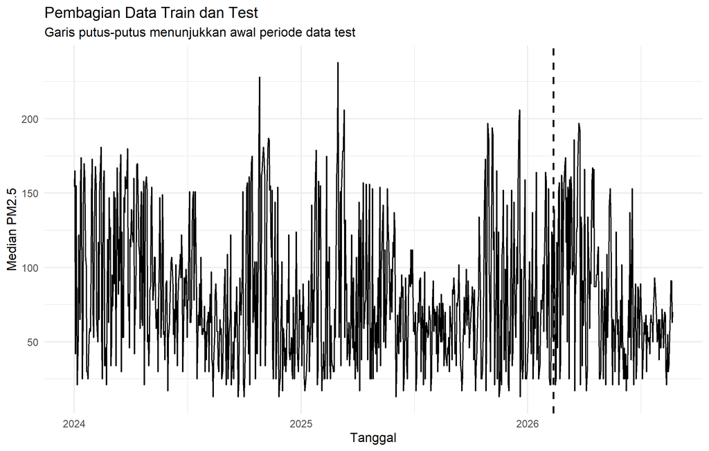

```r
ggplot(data, aes(x = Date, y = median)) +
  geom_line(linewidth = 0.5) +
  geom_vline(
    xintercept = as.numeric(min(test$Date)),
    linetype = "dashed",
    linewidth = 0.8
  ) +
  labs(
    title = "Pembagian Data Train dan Test",
    subtitle = "Garis putus-putus menunjukkan awal periode data test",
    x = "Tanggal",
    y = "Median PM2.5"
  ) +
  theme_minimal()
```

Data train digunakan untuk seluruh proses identifikasi dan estimasi model. Data test disimpan dan tidak digunakan dalam pembentukan model, sehingga dapat digunakan untuk mengevaluasi kemampuan model dalam melakukan peramalan di luar sampel.

# 5 Pemeriksaan Stasioneritas

## 5.1 Stasioneritas dalam Rataan: ACF

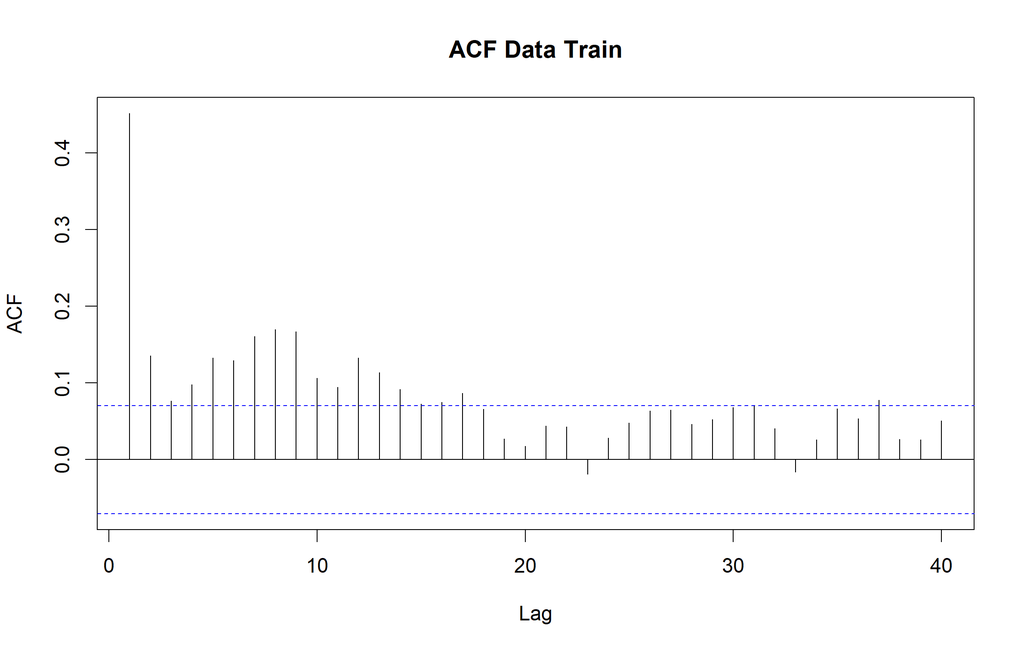

```r
acf(train.ts,
    main = "ACF Data Train",
    lag.max = 40)
```

ACF menunjukkan adanya korelasi serial yang cukup kuat pada beberapa lag awal dengan pola peluruhan secara bertahap. Pola tersebut menjadi indikasi awal adanya ketergantungan antarwaktu pada data, namun keputusan mengenai stasioneritas rataan ditentukan melalui uji ADF.

## 5.2 Uji ADF

Hipotesis yang digunakan:

$$H_0:\text{ data tidak stasioner dalam
rataan}$$

$$H_1:\text{ data stasioner dalam
rataan}$$

```r
adf_level <- tseries::adf.test(train.ts)
adf_level
```

```
#>
#>  Augmented Dickey-Fuller Test
#>
#> data:  train.ts
#> Dickey-Fuller = -6.2086, Lag order = 9, p-value = 0.01
#> alternative hypothesis: stationary
```

Berdasarkan uji Augmented Dickey-Fuller (ADF), diperoleh statistik uji sebesar −6,2086 dengan *p-value* 0,01. Karena *p-value* < 0,05, maka H₀ ditolak sehingga data **stasioner dalam rataan**. Oleh karena itu, tidak diperlukan differencing, sehingga d=0.

## 5.3 Stasioneritas dalam Ragam: Box-Cox

Pemeriksaan stasioneritas dalam ragam dilakukan menggunakan transformasi Box-Cox.

```r
index_train <- seq_along(train.ts)

bc <- MASS::boxcox(
  train.ts ~ index_train,
  lambda = seq(-1, 2, by = 0.01)
)
```

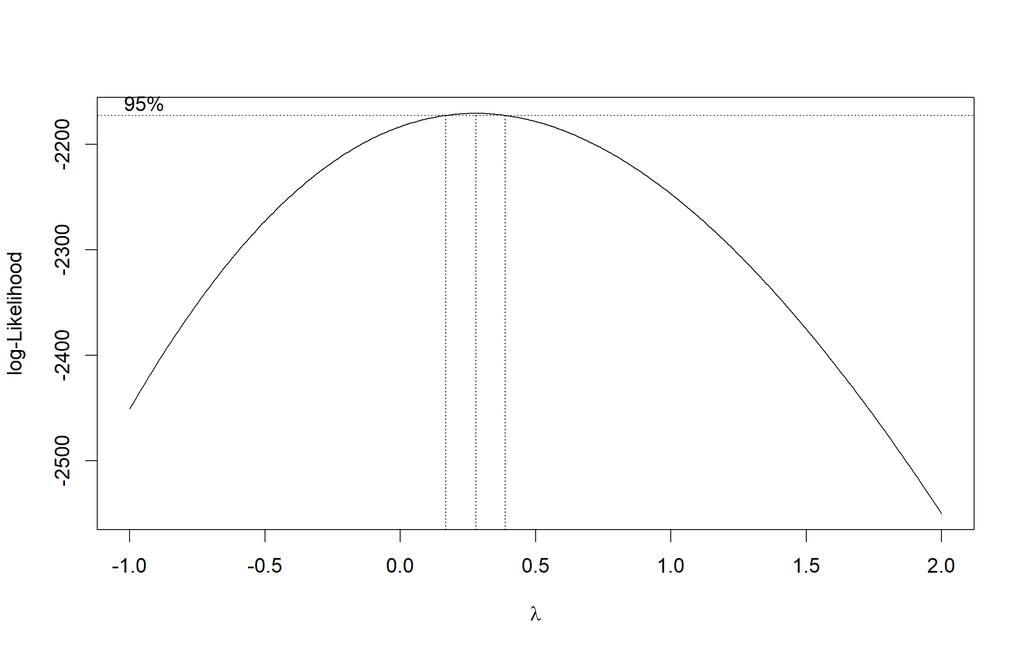

```r
lambda_opt <- bc$x[which.max(bc$y)]

ci_lambda <- bc$x[
  bc$y > max(bc$y) - 0.5 * qchisq(0.95, df = 1)
]

ci_lower <- min(ci_lambda)
ci_upper <- max(ci_lambda)

hasil_boxcox <- data.frame(
  Lambda_Optimum = lambda_opt,
  CI_95_Bawah = ci_lower,
  CI_95_Atas = ci_upper,
  CI_Mengandung_1 = ci_lower <= 1 & ci_upper >= 1
)

hasil_boxcox
```

```
#>   Lambda_Optimum CI_95_Bawah CI_95_Atas CI_Mengandung_1
#> 1           0.28        0.17       0.38           FALSE
```

## 5.4 Keputusan Transformasi Ragam

```r
if (ci_lower <= 1 && ci_upper >= 1) {
  cat("CI 95% lambda mengandung 1 -> transformasi ragam tidak diperlukan.\n")
} else {
  cat("CI 95% lambda tidak mengandung 1 -> transformasi ragam perlu dipertimbangkan.\n")
}
```

```
#> CI 95% lambda tidak mengandung 1 -> transformasi ragam perlu dipertimbangkan.
```

Berdasarkan metode Box-Cox, diperoleh nilai lambda optimum sebesar **0,28** dengan interval kepercayaan 95% sebesar **[0,17; 0,38]**. Interval tersebut tidak mengandung nilai 1, sehingga data belum stasioner dalam ragam. Oleh karena itu, dilakukan transformasi Box-Cox dengan λ=0,28 sebelum tahap identifikasi model ARIMA.

# 6 Penanganan Ketidakstasioneran

## 6.1 Transformasi Box Cox (λ=0,28)

```r
# Transformasi Box-Cox
lambda <- 0.28

train_bc <- forecast::BoxCox(train.ts, lambda = lambda)

# Melihat hasil transformasi
head(train_bc)
```

```
#> Time Series:
#> Start = 1
#> End = 6
#> Frequency = 1
#> [1] 11.062057 11.347494  6.599293 11.088601  8.899746  4.805086
```

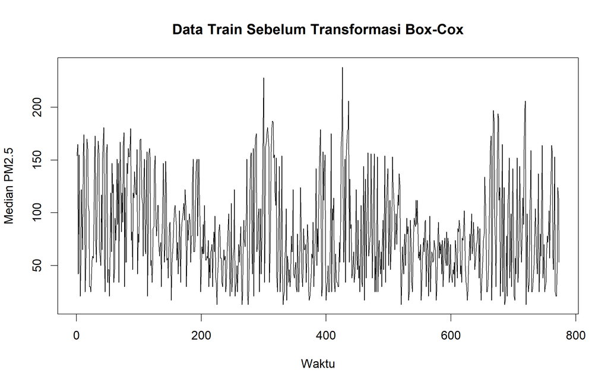

```r
# Plot sebelum transformasi
plot(
  train.ts,
  type = "l",
  main = "Data Train Sebelum Transformasi Box-Cox",
  xlab = "Waktu",
  ylab = "Median PM2.5"
)
```

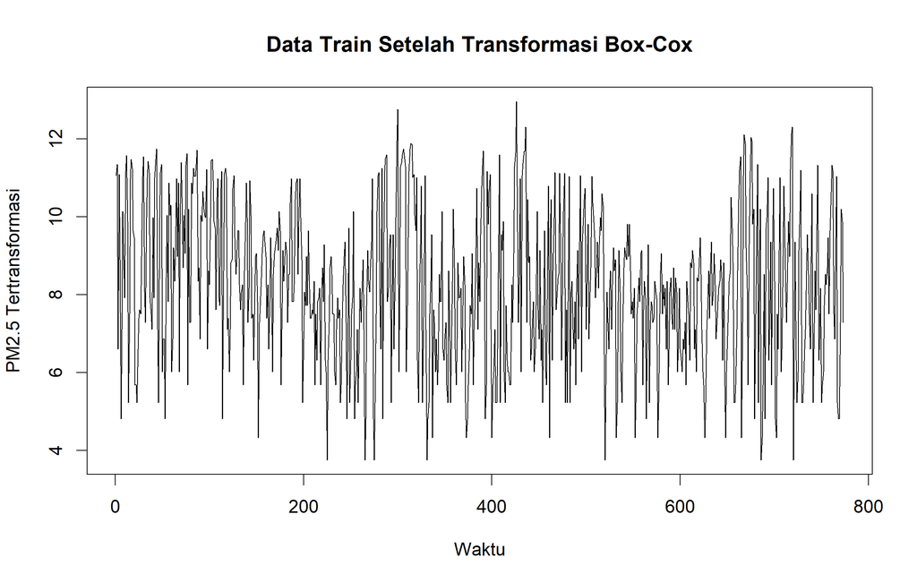

```r
# Plot setelah transformasi
plot(
  train_bc,
  type = "l",
  main = "Data Train Setelah Transformasi Box-Cox",
  xlab = "Waktu",
  ylab = "PM2.5 Tertransformasi"
)
```

# 7 Identifikasi Model ARIMA

Identifikasi model dilakukan menggunakan ACF, PACF, dan EACF. Parameter $d$ ditentukan berdasarkan hasil pemeriksaan stasioneritas sebelumnya.

## 7.1 ACF

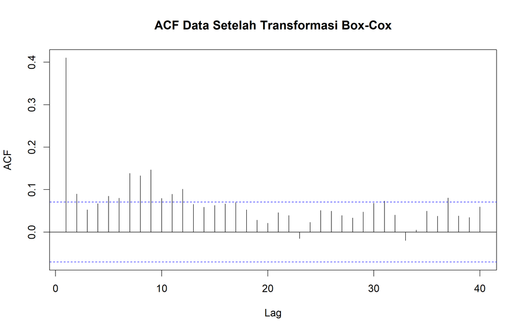

```r
acf(
  train_bc,
  lag.max = 40,
  main = "ACF Data Setelah Transformasi Box-Cox"
)
```

ACF digunakan untuk membantu mengidentifikasi orde MA(q). Pola *cut-off* pada ACF dapat mengindikasikan orde MA, sedangkan pola *tailing off* dapat mengarah pada komponen AR.

## 7.2 PACF

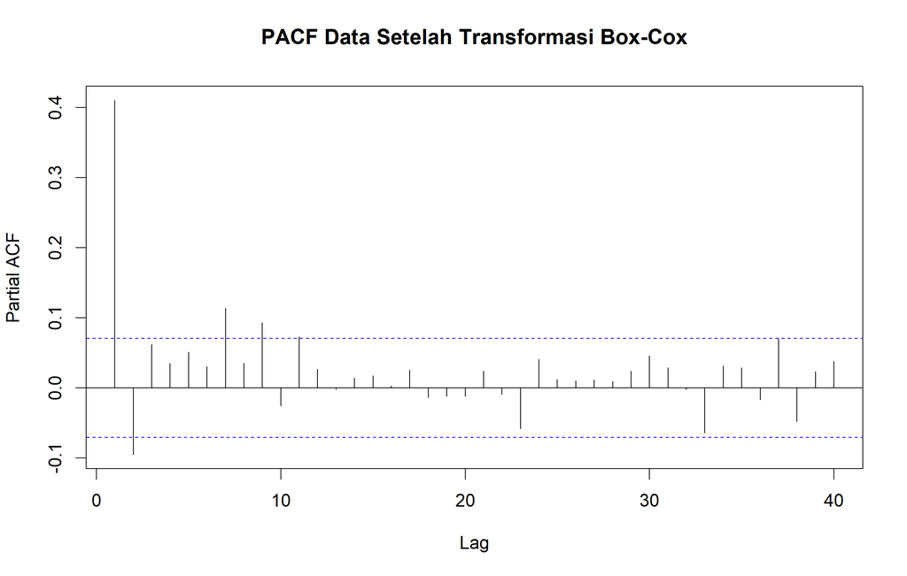

```r
pacf(
  train_bc,
  lag.max = 40,
  main = "PACF Data Setelah Transformasi Box-Cox"
)
```

PACF digunakan untuk membantu mengidentifikasi orde AR(p). Pola *cut-off* pada PACF dapat mengindikasikan orde AR.

## 7.3 Extended ACF (EACF)

```r
TSA::eacf(train_bc)
```

```
#> AR/MA
#>   0 1 2 3 4 5 6 7 8 9 10 11 12 13
#> 0 x x o o x x x x x x x  x  o  o
#> 1 x x o o o o o o x o o  o  o  o
#> 2 x x o o o o o o o o o  o  o  o
#> 3 x x o o o o o o o o o  o  o  o
#> 4 x x o x o o o o x o o  o  o  o
#> 5 x x x x o o o o x o o  o  o  o
#> 6 x x x x x x o o o o o  o  o  o
#> 7 x x x x x x o x o o o  o  o  o
```

EACF digunakan sebagai informasi tambahan untuk menentukan beberapa kandidat model ARMA pada data yang telah stasioner. Nilai $d$ tetap mengikuti hasil pemeriksaan stasioneritas sebelumnya.

## 7.4 Kandidat Model

Berdasarkan plot ACF, terlihat pola penurunan bertahap pada beberapa lag awal yang mengindikasikan adanya komponen autoregresif. Plot PACF menunjukkan spike yang signifikan hingga lag ke-2 dan kemudian relatif berada dalam batas interval kepercayaan, sehingga kandidat orde autoregresif adalah p=2. Hasil EACF memberikan indikasi orde moving average q=2. Dengan d=0, model yang dipertimbangkan pada tahap awal adalah ARIMA(2,0,2).

# 8 Pendugaan Parameter dan Pemilihan Model

Setelah kandidat model ditentukan, masing-masing model diestimasi menggunakan fungsi `Arima()`.

```r
# Estimasi model kandidat
model_101 <- forecast::Arima(
  train_bc, order = c(1, 0, 1), method = "ML")

model_102 <- forecast::Arima(
  train_bc, order = c(1, 0, 2), method = "ML")

model_201 <- forecast::Arima(
  train_bc, order = c(2, 0, 1), method = "ML")

model_202 <- forecast::Arima(
  train_bc, order = c(2, 0, 2), method = "ML")

# Ringkasan model
summary(model_101)
```

```
#> Series: train_bc
#> ARIMA(1,0,1) with non-zero mean
#>
#> Coefficients:
#>          ar1     ma1    mean
#>       0.1935  0.2633  8.2317
#> s.e.  0.0845  0.0837  0.1004
#>
#> sigma^2 = 3.194:  log likelihood = -1544.33
#> AIC=3096.66   AICc=3096.72   BIC=3115.26
#>
#> Training set error measures:
#>                        ME     RMSE     MAE       MPE     MAPE      MASE         ACF1
#> Training set -0.001096793 1.783838 1.43176 -5.707684 19.82744 0.8876999 -0.001211772
```

```r
summary(model_102)
```

```
#> Series: train_bc
#> ARIMA(1,0,2) with non-zero mean
#>
#> Coefficients:
#>          ar1      ma1      ma2    mean
#>       0.9643  -0.5324  -0.3579  8.2428
#> s.e.  0.0219   0.0413   0.0364  0.1916
#>
#> sigma^2 = 3.14:  log likelihood = -1537.24
#> AIC=3084.49   AICc=3084.57   BIC=3107.74
#>
#> Training set error measures:
#>                        ME     RMSE      MAE       MPE     MAPE     MASE        ACF1
#> Training set -0.007137672 1.767396 1.412694 -5.718433 19.63305 0.875879 0.004337123
```

```r
summary(model_201)
```

```
#> Series: train_bc
#> ARIMA(2,0,1) with non-zero mean
#>
#> Coefficients:
#>           ar1     ar2     ma1    mean
#>       -0.4048  0.2832  0.8535  8.2322
#> s.e.   0.0952  0.0603  0.0835  0.1058
#>
#> sigma^2 = 3.189:  log likelihood = -1543.23
#> AIC=3096.46   AICc=3096.53   BIC=3119.71
#>
#> Training set error measures:
#>                        ME     RMSE      MAE     MPE    MAPE      MASE       ACF1
#> Training set -0.001446586 1.781246 1.427797 -5.7015 19.7797 0.8852425 0.01063092
```

```r
summary(model_202)
```

```
#> Series: train_bc
#> ARIMA(2,0,2) with non-zero mean
#>
#> Coefficients:
#>          ar1      ar2      ma1      ma2    mean
#>       1.0003  -0.0335  -0.5639  -0.3336  8.2418
#> s.e.  0.1058   0.0963   0.1003   0.0795  0.1923
#>
#> sigma^2 = 3.144:  log likelihood = -1537.18
#> AIC=3086.36   AICc=3086.47   BIC=3114.27
#>
#> Training set error measures:
#>                        ME     RMSE      MAE       MPE     MAPE      MASE         ACF1
#> Training set -0.006838772 1.767257 1.412308 -5.706387 19.62867 0.8756396 0.0001982728
```

## 8.1 Ringkasan AIC dan BIC

Setelah model kandidat dijalankan, hasilnya diringkas agar mudah dibandingkan.

```r
hasil_model <- data.frame(
  Model = c(
    "ARIMA(1,0,1)",
    "ARIMA(1,0,2)",
    "ARIMA(2,0,1)",
    "ARIMA(2,0,2)"
  ),
  AIC = c(
    AIC(model_101),
    AIC(model_102),
    AIC(model_201),
    AIC(model_202)
  ),
  BIC = c(
    BIC(model_101),
    BIC(model_102),
    BIC(model_201),
    BIC(model_202)
  )
)

hasil_model[order(hasil_model$AIC), ]
```

```
#>          Model      AIC      BIC
#> 2 ARIMA(1,0,2) 3084.487 3107.739
#> 4 ARIMA(2,0,2) 3086.364 3114.265
#> 3 ARIMA(2,0,1) 3096.455 3119.707
#> 1 ARIMA(1,0,1) 3096.663 3115.264
```

```r
lmtest::coeftest(model_101)
```

```
#>
#> z test of coefficients:
#>
#>           Estimate Std. Error z value  Pr(>|z|)
#> ar1       0.193479   0.084472  2.2905  0.021995 *
#> ma1       0.263347   0.083726  3.1454  0.001659 **
#> intercept 8.231708   0.100444 81.9532 < 2.2e-16 ***
#> ---
#> Signif. codes:  0 '***' 0.001 '**' 0.01 '*' 0.05 '.' 0.1 ' ' 1
```

```r
lmtest::coeftest(model_102)
```

```
#>
#> z test of coefficients:
#>
#>            Estimate Std. Error  z value  Pr(>|z|)
#> ar1        0.964287   0.021908  44.0150 < 2.2e-16 ***
#> ma1       -0.532418   0.041307 -12.8892 < 2.2e-16 ***
#> ma2       -0.357870   0.036394  -9.8333 < 2.2e-16 ***
#> intercept  8.242849   0.191635  43.0132 < 2.2e-16 ***
#> ---
#> Signif. codes:  0 '***' 0.001 '**' 0.01 '*' 0.05 '.' 0.1 ' ' 1
```

```r
lmtest::coeftest(model_201)
```

```
#>
#> z test of coefficients:
#>
#>            Estimate Std. Error z value  Pr(>|z|)
#> ar1       -0.404774   0.095163 -4.2535 2.105e-05 ***
#> ar2        0.283177   0.060301  4.6960 2.652e-06 ***
#> ma1        0.853497   0.083466 10.2256 < 2.2e-16 ***
#> intercept  8.232208   0.105792 77.8151 < 2.2e-16 ***
#> ---
#> Signif. codes:  0 '***' 0.001 '**' 0.01 '*' 0.05 '.' 0.1 ' ' 1
```

```r
lmtest::coeftest(model_202)
```

```
#>
#> z test of coefficients:
#>
#>            Estimate Std. Error z value  Pr(>|z|)
#> ar1        1.000283   0.105752  9.4588 < 2.2e-16 ***
#> ar2       -0.033504   0.096334 -0.3478     0.728
#> ma1       -0.563900   0.100290 -5.6227 1.880e-08 ***
#> ma2       -0.333602   0.079464 -4.1982 2.691e-05 ***
#> intercept  8.241789   0.192326 42.8532 < 2.2e-16 ***
#> ---
#> Signif. codes:  0 '***' 0.001 '**' 0.01 '*' 0.05 '.' 0.1 ' ' 1
```

Jadi ARIMA(1,0,2) saat ini merupakan kandidat yang paling kuat untuk dilanjutkan, karena:

- AIC paling kecil
- BIC paling kecil
- seluruh parameternya signifikan

## 8.2 Model Terpilih

Setelah membandingkan seluruh kandidat, masukkan model terpilih pada bagian berikut.

```r
# Model terpilih sementara
model_final <- model_102
```

Model terbaik kemudian digunakan pada tahap diagnostik, overfitting, dan peramalan.

# 9 Analisis Sisaan

Model ARIMA yang baik diharapkan menghasilkan sisaan yang menyerupai *white noise*, yaitu tidak memiliki autokorelasi yang tersisa.

## 9.1 Eksplorasi Sisaan

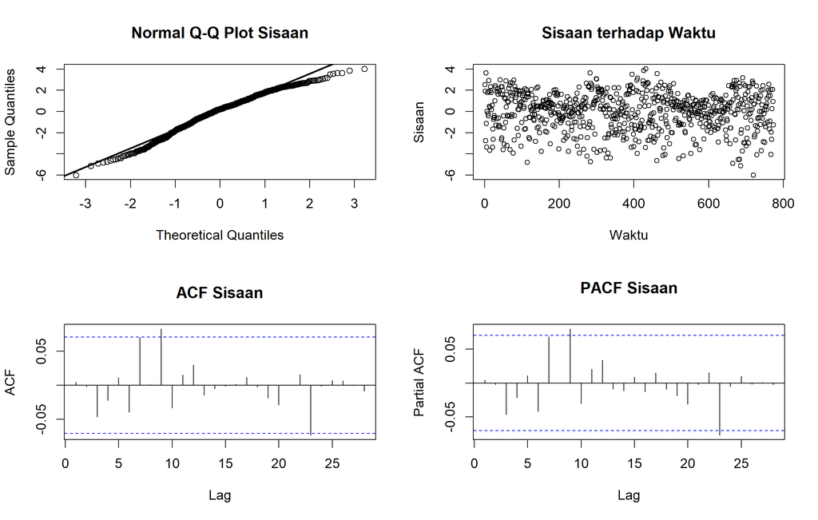

```r
# Sisaan model
sisaan <- residuals(model_final)

par(mfrow = c(2, 2))

# Q-Q Plot
qqnorm(sisaan, main = "Normal Q-Q Plot Sisaan")
qqline(sisaan, lwd = 2)

# Sisaan terhadap waktu
plot(
  sisaan,
  type = "p",
  main = "Sisaan terhadap Waktu",
  xlab = "Waktu",
  ylab = "Sisaan"
)

# ACF sisaan
acf(
  sisaan,
  main = "ACF Sisaan"
)

# PACF sisaan
pacf(
  sisaan,
  main = "PACF Sisaan"
)
```

```r
par(mfrow = c(1, 1))
```

> Secara eksploratif, ACF dan PACF sisaan digunakan untuk melihat apakah masih terdapat autokorelasi. Q-Q plot digunakan untuk melihat kedekatan distribusi sisaan dengan distribusi normal, sedangkan plot sisaan terhadap waktu membantu melihat pola dan perubahan ragam.

## 9.2 Uji Ljung-Box

Hipotesis:

$$H_0:\text{ tidak terdapat autokorelasi
pada sisaan}$$

$$H_1:\text{ terdapat autokorelasi pada
sisaan}$$

```r
Box.test(
  sisaan,
  lag = 20,
  type = "Ljung-Box"
)
```

```
#>
#>  Box-Ljung test
#>
#> data:  sisaan
#> X-squared = 15.537, df = 20, p-value = 0.7449
```

> *p-value* > 0,05, maka tidak terdapat bukti yang cukup untuk menyatakan adanya autokorelasi pada sisaan.

## 9.3 Uji Normalitas

```r
shapiro.test(sisaan)
```

```
#>
#>  Shapiro-Wilk normality test
#>
#> data:  sisaan
#> W = 0.97774, p-value = 1.826e-09
```

Uji ini digunakan sebagai pemeriksaan tambahan terhadap distribusi sisaan.

> Berdasarkan uji Shapiro-Wilk, diperoleh statistik uji sebesar 0.97774 dengan p-value < 0.05. Dengan demikian, H0 ditolak, sehingga terdapat bukti bahwa sisaan model ARIMA(1,0,2) tidak berdistribusi normal.

# 10 Overfitting

Overfitting dilakukan dengan menambahkan satu orde AR atau MA terhadap model terbaik. Tujuannya adalah memeriksa apakah penambahan parameter menghasilkan model yang lebih baik.

Model terbaik adalah ARIMA(1, 0, 2), maka kandidat overfitting dapat berupa:

- Naikkan p: **ARIMA(2,0,2)**
- Naikkan q: **ARIMA(1,0,3)**

Kode berikut merupakan template yang harus disesuaikan dengan model terpilih.

```r
# Model overfitting
model_overfit_p <- forecast::Arima(
  train_bc,
  order = c(2, 0, 2),
  method = "ML"
)

model_overfit_q <- forecast::Arima(
  train_bc,
  order = c(1, 0, 3),
  method = "ML"
)
```

```r
hasil_overfit <- data.frame(
  Model = c(
    "ARIMA(1,0,2)",
    "ARIMA(2,0,2)",
    "ARIMA(1,0,3)"
  ),
  AIC = c(
    AIC(model_102),
    AIC(model_overfit_p),
    AIC(model_overfit_q)
  ),
  BIC = c(
    BIC(model_102),
    BIC(model_overfit_p),
    BIC(model_overfit_q)
  )
)

hasil_overfit[order(hasil_overfit$AIC), ]
```

```
#>          Model      AIC      BIC
#> 1 ARIMA(1,0,2) 3084.487 3107.739
#> 3 ARIMA(1,0,3) 3086.337 3114.239
#> 2 ARIMA(2,0,2) 3086.364 3114.265
```

```r
lmtest::coeftest(model_overfit_p)
```

```
#>
#> z test of coefficients:
#>
#>            Estimate Std. Error z value  Pr(>|z|)
#> ar1        1.000283   0.105752  9.4588 < 2.2e-16 ***
#> ar2       -0.033504   0.096334 -0.3478     0.728
#> ma1       -0.563900   0.100290 -5.6227 1.880e-08 ***
#> ma2       -0.333602   0.079464 -4.1982 2.691e-05 ***
#> intercept  8.241789   0.192326 42.8532 < 2.2e-16 ***
#> ---
#> Signif. codes:  0 '***' 0.001 '**' 0.01 '*' 0.05 '.' 0.1 ' ' 1
```

```r
lmtest::coeftest(model_overfit_q)
```

```
#>
#> z test of coefficients:
#>
#>            Estimate Std. Error z value Pr(>|z|)
#> ar1        0.965868   0.021708  44.494   <2e-16 ***
#> ma1       -0.528567   0.042256 -12.509   <2e-16 ***
#> ma2       -0.350584   0.041052  -8.540   <2e-16 ***
#> ma3       -0.015393   0.039880  -0.386   0.6995
#> intercept  8.243886   0.192617  42.800   <2e-16 ***
#> ---
#> Signif. codes:  0 '***' 0.001 '**' 0.01 '*' 0.05 '.' 0.1 ' ' 1
```

### 10.0.1 Kesimpulan overfitting

Jadi, penambahan orde pada model ARIMA(1,0,2) tidak memberikan perbaikan. Kedua model overfit memiliki parameter tambahan yang tidak signifikan serta AIC dan BIC yang lebih besar.

> Dengan demikian, model ARIMA(1,0,2) dipertahankan sebagai model yang dipilih.

Ini juga konsisten dengan hasil sebelumnya: ARIMA(1,0,2) memiliki AIC dan BIC paling kecil di antara kandidat yang diuji dan seluruh parameternya signifikan.

# 11 Peramalan

## 11.1 Forecast Data Test

Setelah model akhir ditetapkan, dilakukan peramalan sebanyak jumlah observasi pada data test.

```r
# Forecast sebanyak jumlah data test
forecast_final <- forecast::forecast(
  model_final,
  h = nrow(test)
)

forecast_final
```

```
#>     Point Forecast    Lo 80     Hi 80    Lo 95    Hi 95
#> 774       7.660771 5.389879  9.931663 4.187742 11.13380
#> 775       8.141211 5.667595 10.614827 4.358141 11.92428
#> 776       8.144841 5.667651 10.622031 4.356305 11.93338
#> 777       8.148341 5.667832 10.628850 4.354730 11.94195
#> 778       8.151716 5.668125 10.635307 4.353392 11.95004
#> 779       8.154971 5.668518 10.641424 4.352269 11.95767
#> 780       8.158109 5.668998 10.647220 4.351342 11.96488
#> 781       8.161135 5.669555 10.652716 4.350591 11.97168
#> 782       8.164054 5.670179 10.657929 4.350001 11.97811
#> 783       8.166868 5.670862 10.662874 4.349556 11.98418
#> 784       8.169581 5.671595 10.667567 4.349241 11.98992
#> 785       8.172198 5.672372 10.672024 4.349044 11.99535
#> 786       8.174721 5.673186 10.676256 4.348953 12.00049
#> 787       8.177154 5.674030 10.680278 4.348956 12.00535
```

[output cut: 179 more lines]

## 11.2 Plot Forecast

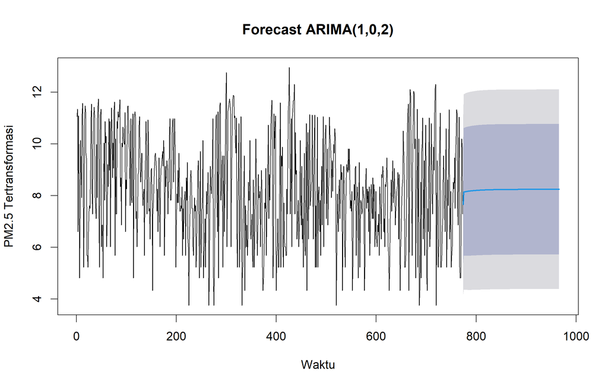

```r
plot(
  forecast_final,
  main = "Forecast ARIMA(1,0,2)",
  xlab = "Waktu",
  ylab = "PM2.5 Tertransformasi"
)
```

## 11.3 Perbandingan Aktual dan Forecast

```r
lambda <- 0.28

# Forecast mean dikembalikan ke skala asli
forecast_original <- forecast::InvBoxCox(
  forecast_final$mean,
  lambda = lambda
)

# Interval prediksi dikembalikan ke skala asli
lower_original <- forecast::InvBoxCox(
  forecast_final$lower,
  lambda = lambda
)

upper_original <- forecast::InvBoxCox(
  forecast_final$upper,
  lambda = lambda
)
```

## 11.4 Plot Aktual vs Forecast

```r
hasil_forecast <- data.frame(
  Date = test$Date,
  Aktual = test$median,
  Forecast = as.numeric(forecast_original),
  Lower_95 = as.numeric(lower_original[, 1]),
  Upper_95 = as.numeric(upper_original[, 1])
)

head(hasil_forecast)
```

```
#>         Date Aktual Forecast Lower_95 Upper_95
#> 1 2026-02-12    119 59.87210 26.72335 115.5649
#> 2 2026-02-13    139 69.53262 29.80087 137.8408
#> 3 2026-02-14     82 69.60961 29.80151 138.0910
#> 4 2026-02-15     21 69.68391 29.80360 138.3281
#> 5 2026-02-16     25 69.75561 29.80698 138.5528
#> 6 2026-02-17    117 69.82480 29.81150 138.7660
```

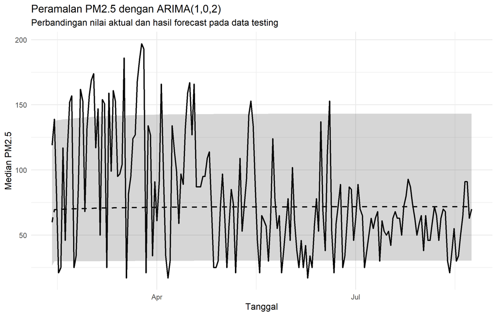

```r
ggplot(hasil_forecast, aes(x = Date)) +
  geom_line(
    aes(y = Aktual),
    linewidth = 0.8
  ) +
  geom_line(
    aes(y = Forecast),
    linewidth = 0.8,
    linetype = "dashed"
  ) +
  geom_ribbon(
    aes(
      ymin = Lower_95,
      ymax = Upper_95
    ),
    alpha = 0.2
  ) +
  labs(
    title = "Peramalan PM2.5 dengan ARIMA(1,0,2)",
    subtitle = "Perbandingan nilai aktual dan hasil forecast pada data testing",
    x = "Tanggal",
    y = "Median PM2.5"
  ) +
  theme_minimal()
```

## 11.5 Akurasi Forecast

```r
MAE <- mean(
  abs(hasil_forecast$Aktual - hasil_forecast$Forecast),
  na.rm = TRUE
)

RMSE <- sqrt(
  mean(
    (hasil_forecast$Aktual - hasil_forecast$Forecast)^2,
    na.rm = TRUE
  )
)

MAPE <- mean(
  abs(
    (hasil_forecast$Aktual - hasil_forecast$Forecast) /
      hasil_forecast$Aktual
  ),
  na.rm = TRUE
) * 100

akurasi <- data.frame(
  MAE = MAE,
  RMSE = RMSE,
  MAPE = MAPE
)

akurasi
```

```
#>        MAE     RMSE     MAPE
#> 1 34.64879 44.66104 59.12324
```

> Nilai MAE sebesar 34,65, RMSE sebesar 44,66, dan MAPE sebesar 59,12% menunjukkan besarnya kesalahan peramalan pada data testing.

# 12 Kesimpulan

Berdasarkan hasil pemodelan deret waktu data median PM2.5, diperoleh bahwa data train telah stasioner dalam rataan berdasarkan uji Augmented Dickey-Fuller (ADF) dengan p-value sebesar 0,01 < 0,05, sehingga tidak diperlukan differencing dan diperoleh orde d = 0. Namun, data belum stasioner dalam ragam karena interval kepercayaan 95% lambda Box-Cox sebesar [0,17; 0,38] tidak mengandung nilai 1. Oleh karena itu, dilakukan transformasi Box-Cox dengan lambda sebesar 0,28.

Berdasarkan identifikasi ACF, PACF, dan EACF, diperoleh beberapa model kandidat ARIMA. Setelah mempertimbangkan signifikansi parameter serta nilai AIC dan BIC, model ARIMA(1,0,2) dipilih dengan AIC sebesar 3084,487 dan BIC sebesar 3107,739. Seluruh parameter model tersebut signifikan secara statistik.

Hasil analisis sisaan menunjukkan bahwa sisaan tidak berdistribusi normal berdasarkan uji Shapiro-Wilk. Namun, uji Ljung-Box menghasilkan p-value sebesar 0,7449 > 0,05, sehingga tidak terdapat bukti adanya autokorelasi pada sisaan. Dengan demikian, sisaan telah memenuhi karakteristik white noise dari aspek autokorelasi.

Hasil overfitting dengan model ARIMA(2,0,2) dan ARIMA(1,0,3) menunjukkan bahwa parameter tambahan pada kedua model tidak signifikan dan nilai AIC maupun BIC lebih besar dibandingkan ARIMA(1,0,2). Oleh karena itu, ARIMA(1,0,2) dipertahankan sebagai model akhir.

Peramalan terhadap 193 observasi data testing menghasilkan nilai MAE sebesar 34,65, RMSE sebesar 44,66, dan MAPE sebesar 59,12%. Nilai tersebut digunakan untuk menggambarkan besarnya kesalahan peramalan model terhadap data aktual pada periode testing.